# Reproducible Research: Peer Assessment 1

```r
library(lattice)
```

## Loading and preprocessing the data

Load CSV data **activity.csv** and convert dates to **R Date type**

```r
activitydata <- read.csv("activity.csv")
activitydata$date <- as.Date(activitydata$date,"%Y-%m-%d")
head(activitydata)
```

```
##   steps       date interval
## 1    NA 2012-10-01        0
## 2    NA 2012-10-01        5
## 3    NA 2012-10-01       10
## 4    NA 2012-10-01       15
## 5    NA 2012-10-01       20
## 6    NA 2012-10-01       25
```

## What is mean total number of steps taken per day?

1. Split data by day and calculate steps in each one
2. Plot the histogramme
3. Calculate mean and median

Compute total number of steps per day

```r
totsteps <- tapply(activitydata$steps, activitydata$date,sum)
```

Plot histogram of **total number of steps per day**

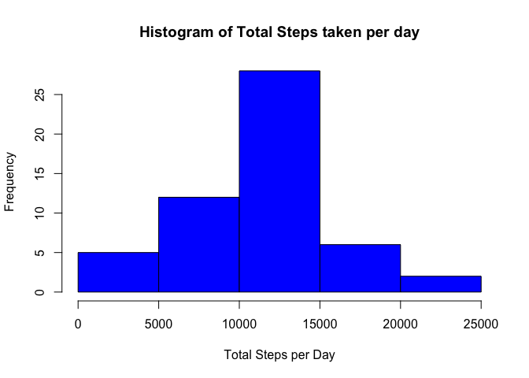

```r
hist(totsteps,col="blue",xlab="Total Steps per Day",
        ylab="Frequency", main="Histogram of Total Steps taken per day")
```

Compute Mean total steps taken per day

```r
mean(totsteps,na.rm=TRUE)
```

```
## [1] 10766.19
```

Compute Median total steps taken per day

```r
median(totsteps,na.rm=TRUE)
```

```
## [1] 10765
```

## What is the average daily activity pattern?

1. Split data by intervals.
2. Calculate average of steps in each 5 minutes interval.
3. Plot 5-minute interval (x-axis) and the average number of steps taken, averaged across all days (y-axis).
4. Find the interval that contain maximum number of steps.

Compute mean of steps over all days by time interval

```r
meansteps <- tapply(activitydata$steps,activitydata$interval,
                                 mean,na.rm=TRUE)
```

Timeseries plot of of the 5-minute interval and the average number of steps taken, averaged across all days

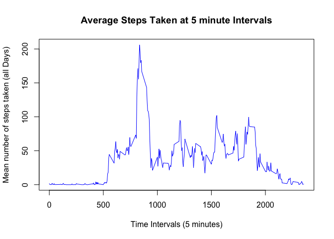

```r
plot(row.names(meansteps),meansteps,type="l",
     xlab="Time Intervals (5 minutes)",
     ylab="Mean number of steps taken (all Days)",
     main="Average Steps Taken at 5 minute Intervals",
     col="blue")
```

Find the time interval that contains maximum average number of steps over all days

```r
interval_num <- which.max(meansteps)
interval_max_steps <- names(interval_num)
interval_max_steps
```

```
## [1] "835"
```

The ** 835** minute or ** 104th ** 5 minute interval contains the maximum number of steps on average across all the days

## Imputing missing values

Compute the number of NA values in the activity dataset

```r
na_values <- sum(is.na(activitydata))
na_values
```

```
## [1] 2304
```

Fill in missing values using the **average interval value across all days**

```r
na_indices <-  which(is.na(activitydata))
imputed_values <- meansteps[as.character(activitydata[na_indices,3])]
names(imputed_values) <- na_indices
for (i in na_indices) {
    activitydata$steps[i] = imputed_values[as.character(i)]
}
sum(is.na(activitydata))
```

```
## [1] 0
```

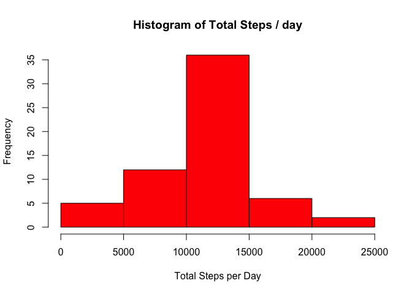

```r
totsteps <- tapply(activitydata$steps, activitydata$date,sum)
hist(totsteps,col="red",xlab="Total Steps per Day",
      ylab="Frequency", main="Histogram of Total Steps / day")
```

## Are there differences in activity patterns between weekdays and weekends?

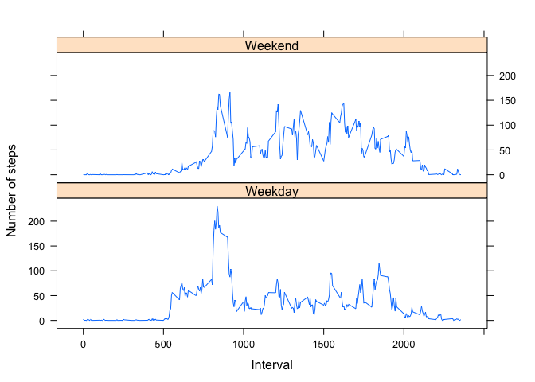

```r
days <- weekdays(activitydata$date)
activitydata$day_type <- ifelse(days == "Saturday" | days == "Sunday",
                                "Weekend", "Weekday")
meansteps <- aggregate(activitydata$steps,
                                    by=list(activitydata$interval,
                                            activitydata$day_type),mean)
names(meansteps) <- c("interval","day_type","steps")
xyplot(steps~interval | day_type, meansteps,type="l",
       layout=c(1,2),xlab="Interval",ylab = "Number of steps")
```

Compute the min, max, mean, median of the steps across all intervals and days by weekdays/weekends

```r
tapply(meansteps$steps,meansteps$day_type,
       function (x) { c(MINIMUM=min(x),MEAN=mean(x),
                        MEDIAN=median(x),MAXIMUM=max(x))})
```

```
## $Weekday
##   MINIMUM      MEAN    MEDIAN   MAXIMUM
##   0.00000  35.61058  25.80314 230.37820
##
## $Weekend
##   MINIMUM      MEAN    MEDIAN   MAXIMUM
##   0.00000  42.36640  32.33962 166.63915
```